```python
import numpy as np
import matplotlib.pyplot as plt
from scipy.stats import norm
import math
import random
```

# Monte Carlo Simulation

## Pi Calculation

To estimate the value of Pi using Monte Carlo simulation, we follow the idea of generating random points within a square that bounds a circle. The circle has a radius *r*, and the square has sides of length *2r*, ensuring that the circle is inscribed within the square. The area of the circle is *πr<sup>2</sup>*, and the area of the square is *(2r)<sup>2</sup> = 4r<sup>2</sup>*. The ratio of the area of the circle to the area of the square is therefore *πr<sup>2</sup> / 4r<sup>2</sup> = π / 4*.

By randomly generating points within the square, we can estimate Pi by comparing the number of points that fall inside the circle to the total number of points. The ratio of points inside the circle to the total points, multiplied by 4, gives us an approximation of Pi.

```python
def estimate_pi(num_points):
    points_inside_circle = 0
    for _ in range(num_points):
        # Generate random points within the square [-1, 1] x [-1, 1]
        x, y = random.uniform(-1, 1), random.uniform(-1, 1)
        distance = x**2 + y**2  # Calculate the distance from the origin
        if distance <= 1:  # Check if the point is inside the circle
            points_inside_circle += 1
    # Estimate Pi using the ratio of points inside the circle to total points
    pi_estimate = 4 * points_inside_circle / num_points
    return pi_estimate

# Estimate Pi using 1000 points
pi_estimate_10000 = estimate_pi(1000)
print(f"Estimated Pi using 1000 points: {pi_estimate_10000}")

# Estimate Pi using 10,000 points
pi_estimate_10000 = estimate_pi(10000)
print(f"Estimated Pi using 10,000 points: {pi_estimate_10000}")

# Estimate Pi using 100,000 points
pi_estimate_100000 = estimate_pi(100000)
print(f"Estimated Pi using 100,000 points: {pi_estimate_100000}")
```

```
Estimated Pi using 1000 points: 3.192
Estimated Pi using 10,000 points: 3.1664
Estimated Pi using 100,000 points: 3.14324
```

## Mensch Game

```python
import numpy as np

def simulate_mensch(num_simulations):
    wins = np.zeros(4)  # Track wins for each player

    for _ in range(num_simulations):
        positions = np.full(4, -1)# -1 indicates the piece is not yet on the board
        initpos = [0, 10, 20, 30]
        home = [40, 50, 60, 70]
        while True:
      #  for i in range(1000):
            for player in range(4):
                roll = np.random.randint(1, 7)  # Simulate dice roll
            #    print(player, " ", roll, " ", positions)
                # Check if player can start or re-enter the game
                if positions[player] == -1:
                    if roll == 6:
                        positions[player] = initpos[player]  # Enter the game
                else:
                    potential_move = (positions[player] + roll)
                    # Check if move is within winning bounds and if not, skip the move
                    if potential_move <= home[player]:
                        # Check for collision
                        for opponent in range(4):
                            if opponent != player and (positions[opponent] % 40) == (potential_move % 40):
                                positions[opponent] = -1  # Send opponent's piece off the board
                        positions[player] = potential_move  # Make the valid move

                    # Adjust for exact winning condition
                    else:
                        continue

                # Check for a winner
                if positions[player] == home[player]:
                    wins[player] += 1
                    break  # Break from the player loop to start a new game
            if np.any(positions == home): # Check if there's a winner to end the game
                break

    probabilities = wins / num_simulations  # Calculate winning probabilities
    return probabilities

# Simulate the game different times
probabilities = simulate_mensch(100)
print(probabilities)
probabilities = simulate_mensch(1000)
print(probabilities)
probabilities = simulate_mensch(10000)
print(probabilities)
```

```
[0.34 0.2  0.25 0.21]
[0.275 0.233 0.264 0.228]
[0.2651 0.2512 0.2429 0.2408]
```

# Central Limit Theorem(CLT)

The objective of this section is to provide you with a hands-on opportunity to observe and understand the Central Limit Theorem in action. The CLT is a fundamental result that supports many statistical techniques and methods. It provides a theoretical basis for making inferences about population parameters based on sample statistics.  
First of all, select three different probability distributions. These distributions will serve as the population distributions from which you will take out samples.  
Now for each of the distributions, perform the following steps:

1. Generate a large number of random samples with a specific sample size from the chosen distribution.
2. Calculate the mean of each sample.
3. Plot the histogram of the sample means and overlay it with the expected normal distribution based on the Central Limit Theorem.
4. Repeat steps a to c for increasing sample sizes and observe how the distribution of sample means changes as we increase the sample size.

Document your observations and insights from each experiment. Compare the distribution of sample means for each sample size and discuss how they align with the principles of the Central Limit Theorem.

## Implementation:

```python
colors = ['darkgreen', 'green', 'forestgreen', 'mediumseagreen','teal',
          'darkcyan', 'deepskyblue', 'dodgerblue', 'blue',
          'navy', 'indigo', 'darkslateblue', 'darkorchid']
```

```python
sample_sizes = [1, 5, 10, 30, 50, 100, 500, 1000]
```

```python
def demonstrate_clt(population_distribution, dist_name, sample_sizes):
    # Determine the number of rows and columns based on the number of sample sizes
    n = len(sample_sizes)
    rows = math.ceil(n / 2)
    cols = 2 if n > 1 else 1

    plt.figure(figsize=(18, 6 * rows))
    for i, sample_size in enumerate(sample_sizes, 1):
        #1.Generate a large number of random samples.
        #2. Calculate the mean of each sample.
        sample_means = [np.mean(population_distribution(size=sample_size)) for _ in range(1000)]

        #Calculate mean and variance of the sample means
        mean_of_sample_means = np.mean(sample_means)
        variance_of_sample_means = np.var(sample_means)

        #3.1 Plot the histogram of the sample means
        plt.subplot(rows, cols, i)
        plt.hist(sample_means, bins=30, density=True, alpha=0.6, color=colors[-i], label=f'Sample Means (n={sample_size})')

        #3.2 Overlay it with the expected normal distribution.
        mu, sigma = mean_of_sample_means, np.std(sample_means)
        xmin, xmax = plt.xlim()
        x = np.linspace(xmin, xmax, 100)
        p = norm.pdf(x, mu, sigma)
        plt.plot(x, p, 'k', linewidth=2, label='Normal Distribution')

        # Include mean and variance in the title or as a text annotation
        plt.title(f'{dist_name} (n={sample_size})\nMean: {mean_of_sample_means:.5f}, Variance: {variance_of_sample_means:.5f}')
        plt.legend()

    plt.tight_layout()
    plt.show()
```

### 1. Uniform Distribution:

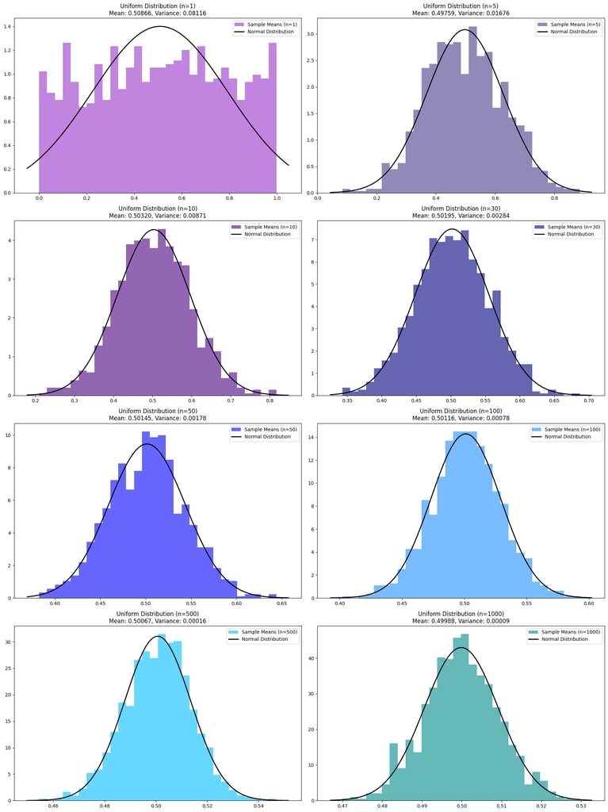

```python
demonstrate_clt(lambda size: np.random.uniform(low=0, high=1, size=size), 'Uniform Distribution', sample_sizes)
```

#### Uniform Distribution Observations:

- **n=1**: The sample mean distribution is quite irregular and does not resemble a normal distribution, as expected for a small sample size.
- **n=5**: A slight bell shape begins to emerge, indicating the beginning of convergence towards a normal distribution, although the distribution is still quite wide with considerable variance.
- **n=10 to n=30**: The histogram shows a more defined bell shape, aligning more closely with the normal distribution overlaid on the graph. Variance has decreased, suggesting the distribution of sample means is starting to stabilize.
- **n=50 to n=1000**: The histogram tightly aligns with the normal distribution curve. The mean of the sample means remains consistent around 0.5, the midpoint of the uniform distribution, and the variance continues to decrease, showcasing the convergence predicted by the CLT.

### 2. Exponential Distribution

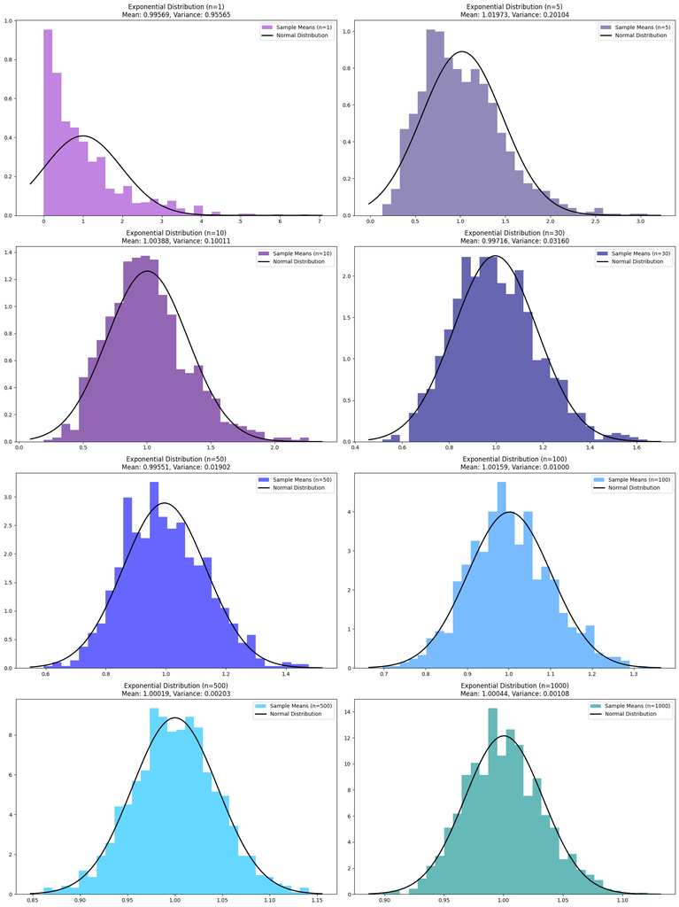

```python
demonstrate_clt(lambda size: np.random.exponential(scale=1, size=size), 'Exponential Distribution', sample_sizes)
```

#### Exponential Distribution Observations:

- **n=1**: The sample means are skewed right, which is characteristic of the exponential distribution. The shape does not resemble a normal distribution.
- **n=5**: There's a noticeable improvement towards a bell shape, yet the right skew is still present.
- **n=10 to n=30**: The distribution of sample means becomes more symmetric and starts resembling a normal distribution, although the fit isn't perfect yet.
- **n=50 to n=1000**: The histograms are now very close to the overlaid normal distribution, with the mean of sample means converging towards the theoretical mean of the exponential distribution. The variance is reducing, which indicates a higher precision in the estimation of the mean with larger sample sizes.

### 3. Binomial Distribution

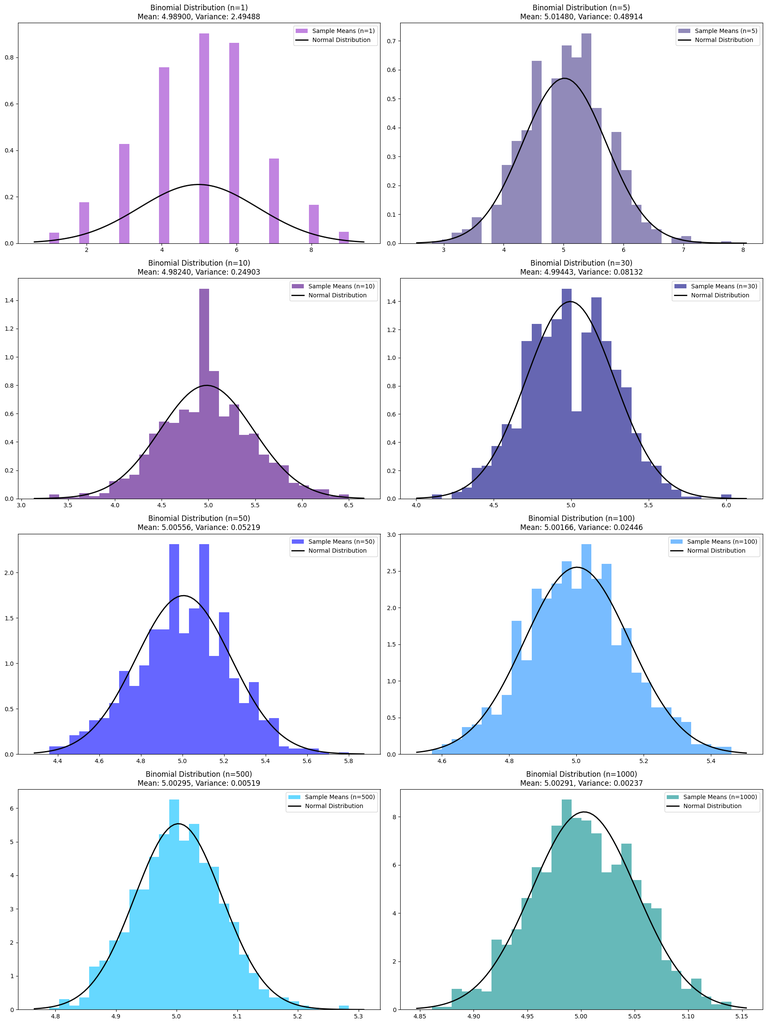

```python
demonstrate_clt(lambda size: np.random.binomial(n=10, p=0.5, size=size), 'Binomial Distribution', sample_sizes)
```

#### Binomial Distribution Observations:

- **n=1**: The sample means are highly discrete and irregular due to the nature of the binomial distribution and the small sample size.
- **n=5**: The distribution begins to smooth out but still shows significant variability and some skewness.
- **n=10 to n=30**: The histogram starts to take on a more bell-shaped curve, although it's not yet a perfect fit with the normal distribution.
- **n=50 to n=1000**: The distribution of sample means aligns closely with the normal distribution. The mean of the sample means converges on the expected value of the binomial distribution, and the variance reduces substantially, supporting the CLT.

## Analysis and Insights:

- The histograms present empirical evidence that the sampling distribution of the mean typically normalizes, affirming the central assertion of the Central Limit Theorem (CLT).
- With increasing sample sizes across all three distributions, the convergence of sample mean histograms to a normal distribution is observed, supporting the CLT.
- A noted decrease in the variance of sample means with larger sample sizes suggests a more precise estimation of the population mean.
- The pace of convergence to the normal distribution may differ based on the original distribution's characteristics. In these experiments, sample means from the uniform distribution tended to resemble a normal distribution more quickly than those from the exponential and binomial distributions, likely due to its inherent symmetry and absence of skew.
- For initially skewed or discrete distributions such as exponential and binomial, a greater number of samples is required to closely approximate a normal distribution compared to the uniform distribution.

### Conclusion:

The experiments corroborate the Central Limit Theorem's predictions. They illustrate that the distribution of sample means tends toward normality irrespective of the population distribution's form, contingent on a large enough sample size. This evidence bears significant weight for statistical inference, offering a foundation for constructing predictions and confidence intervals regarding population parameters derived from sample statistics.

# Hypothesis Testing

Hypothesis testing provides a structured framework for evaluating and either accepting or rejecting new hypotheses in contrast to existing ones. The hypothesis previously accepted is termed the **Null Hypothesis**, while the one challenging established notions is termed the **Alternative Hypothesis**. These tests involve analyzing a sample according to both hypotheses and comparing their outcomes, acknowledging a significance level that weighs minor improvements suggested by the alternative hypothesis. To discern the results, a critical region is delineated, encompassing all plausible outcomes consistent with the alternative hypothesis while favoring the most probable outcome suggested by the sample.

## Coin Toss

```python
from typing import *
import numpy as np
import matplotlib.pyplot as plt
from scipy.stats import norm
```

```python
class UnfairCoin:
    p_head  = 0.55

class Result:
    def __init__(self, sample_size, z_score, p_value, confidence_interval, ci_decision, p_decision):
        self.sample_size = sample_size
        self.z_score = z_score
        self.p_value = p_value
        self.confidence_interval = confidence_interval
        self.ci_decision = ci_decision
        self.p_decision = p_decision

    def __repr__(self):
        s = f"Sample Size: {self.sample_size}\n"
        s += f"Z_score: {self.z_score}\n"
        s += f"P_value: {self.p_value}\n"
        s += f"Confidence Interval: {self.confidence_interval}\n"
        s += f"Decision made by the confidence interval: {self.ci_decision}\n"
        s += f"Decision made by P-value: {self.p_decision}"
        return s
    def __str__(self):
        return self.__repr__()
```

```python
def get_coin_tosses(sample_size):
    return np.random.choice([0, 1], n, p=[1 - UnfairCoin.p_head, UnfairCoin.p_head])
```

```python
def test_coin_tosses(coin_tosses, alpha):
    sample_size = len(coin_tosses)
    prop_heads = np.mean(coin_tosses)
    std_error = np.sqrt((prop_heads * (1 - prop_heads)) / sample_size)
    z_score = (prop_heads - 0.50) / std_error
    p_value = 2 * (1 - norm.cdf(np.abs(z_score)))

    margin_error = norm.ppf(1 - alpha/2) * std_error
    ci_lower = prop_heads - margin_error
    ci_upper = prop_heads + margin_error
    confidence_interval = (ci_lower, ci_upper)

    # Decision based on confidence interval
    if ci_lower <= 0.50 <= ci_upper:
        ci_decision = "Reject null hypothesis"
    else:
        ci_decision = "Fail to reject null hypothesis"

    # Decision based on p-value
    if p_value < alpha:
        p_decision = "Reject null hypothesis"
    else:
        p_decision = "Fail to reject null hypothesis"

    test_result = Result(sample_size, z_score, p_value, confidence_interval, ci_decision, p_decision)
    return test_result
```

```python
for n in [30, 100, 1000]:
    coin_tosses = get_coin_tosses(sample_size=n)
    test_result = test_coin_tosses(coin_tosses, 0.05)

    print(test_result)
    print("-" * 20)
```

```
Sample Size: 30
Z_score: 0.0
P_value: 1.0
Confidence Interval: (0.32108058562828434, 0.6789194143717157)
Decision made by the confidence interval: Reject null hypothesis
Decision made by P-value: Fail to reject null hypothesis
--------------------
Sample Size: 100
Z_score: 0.20004001200400157
P_value: 0.8414492884433384
Confidence Interval: (0.4120214023731988, 0.6079785976268013)
Decision made by the confidence interval: Reject null hypothesis
Decision made by P-value: Fail to reject null hypothesis
--------------------
Sample Size: 1000
Z_score: 3.499743313364458
P_value: 0.0004657063713437992
Confidence Interval: (0.5241983069906713, 0.5858016930093288)
Decision made by the confidence interval: Fail to reject null hypothesis
Decision made by P-value: Reject null hypothesis
--------------------
```

## Job Placement

```python
from typing import *
import pandas as pd
import numpy as np
import matplotlib.pyplot as plt
from scipy.stats import t, ttest_ind
from scipy.optimize import curve_fit
```

$$ SE = \sqrt{\frac{s_1^2}{n_1} + \frac{s_2^2}{n_2}} $$ $$ t-statistic = \frac{\bar{x_1} - \bar{x_2}}{SE} $$

```python
class TTest:
    def __init__(self: Self, group1: pd.Series, group2: pd.Series):
        self.group1 = group1
        self.group2 = group2

    def show_group1(self: Self):
        TTest._show_distribution(self.group1)
    def show_group2(self: Self):
        TTest._show_distribution(self.group2)
    def show_all(self: Self):
        data = pd.concat([self.group1, self.group2])
        TTest._show_distribution(self.group1)

    def _show_distribution(data: pd.Series):
        min_value = np.floor(data.min())
        max_value = np.ceil(data.max())
        bins = np.arange(min_value, max_value, 0.1) - 0.05
        plt.hist(data,
                 bins=bins,
                 edgecolor='black')

    def calculate_t_statistic(self):
        n1 = len(self.group1)
        n2 = len(self.group2)
        mean1 = self.group1.mean()
        mean2 = self.group2.mean()
        var1 = self.group1.var()
        var2 = self.group2.var()
        t_statistic = (mean1 - mean2) / np.sqrt((var1 / n1) + (var2 / n2))
        return t_statistic

    def calculate_degree_of_freedom(self):
        n1 = len(self.group1)
        n2 = len(self.group2)
        var1 = self.group1.var()
        var2 = self.group2.var()
        df = n1 + n2 - 2
        return df

    def calculate_p_value(self):
        t_statistic = self.calculate_t_statistic()
        df = self.calculate_degree_of_freedom()
        return 1 - t.cdf(t_statistic, df)

    def make_decision(self, alpha):
        p_value = self.calculate_p_value()
        if p_value < alpha:
            return "Reject null hypothesis"
        else:
            return "Fail to reject null hypothesis"

    def get_t_statistic_and_p_value_scipy(self):
        t_statistic, p_value = ttest_ind(self.group1, self.group2)
        return t_statistic, p_value
    def make_decision_scipy(self, alpha):
        t_statistic, p_value = self.get_t_statistic_and_p_value_scipy()
        if p_value < alpha:
            return "Reject null hypothesis"
        else:
            return "Fail to reject null hypothesis"
```

```python
df = pd.read_csv("data/job_placement.csv")
ttest_obj = TTest(
    df[df['placement_status'] == 'Placed']['gpa'], \
    df[df['placement_status'] == 'Not Placed']['gpa'])
```

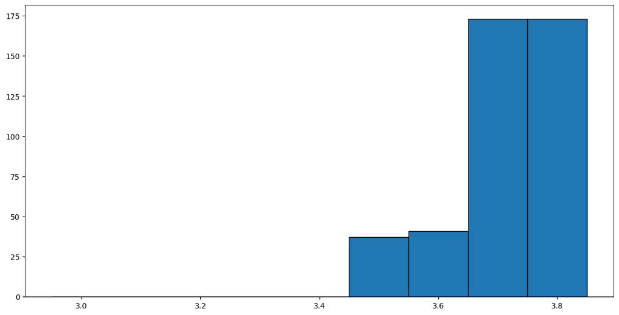

```python
plt.figure(figsize=(14, 7))
ttest_obj.show_all()
plt.show()
```

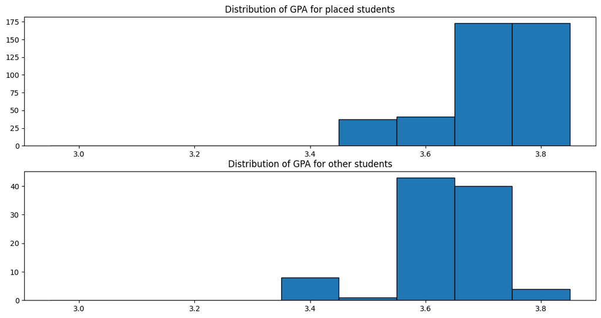

```python
plt.figure(figsize=(14, 7))
plt.subplot(2, 1, 1)
plt.title("Distribution of GPA for placed students")
ttest_obj.show_group1()
plt.subplot(2, 1, 2)
plt.title("Distribution of GPA for other students")
ttest_obj.show_group2()
plt.show()
```

### Computations

```python
ttest_obj.calculate_t_statistic()
```

```
4.442633347555537
```

```python
ttest_obj.calculate_degree_of_freedom()
```

```
698
```

```python
ttest_obj.calculate_p_value()
```

```
5.165578960020234e-06
```

```python
ttest_obj.make_decision(0.05)
```

```
'Reject null hypothesis'
```

### Computation and Testing by Scipy

```python
ttest_obj.get_t_statistic_and_p_value_scipy()
```

```
(5.105318956468754, 4.263644494096789e-07)
```

```python
ttest_obj.make_decision_scipy(0.05)
```

```
'Reject null hypothesis'
```

# Questions:

**1. Read a little bit about the applications of Monte Carlo Simulation in real life. What are some of these applications?**

1. Finance and Investment: Monte Carlo simulation is extensively used in financial modeling to assess the risk associated with investment portfolios, options pricing, and asset allocation strategies. It helps investors and financial analysts make informed decisions by providing insights into potential outcomes under different market conditions.
2. Insurance: Insurance companies utilize Monte Carlo simulation to evaluate and manage risks associated with insurance policies, such as assessing the likelihood of claims, estimating reserves, and determining premium rates. It helps insurers optimize their risk exposure and pricing strategies.
3. Engineering and Manufacturing: Monte Carlo simulation is employed in engineering and manufacturing to analyze the reliability and performance of complex systems, such as aerospace components, automotive designs, and industrial processes. It assists engineers in identifying potential failure points, optimizing designs, and improving product quality.
4. Project Management: Monte Carlo simulation is used in project management to assess project schedules, budgets, and resource allocations. It enables project managers to identify critical paths, estimate project completion times, and evaluate the impact of uncertainties and risks on project outcomes.
5. Healthcare and Medicine: Monte Carlo simulation plays a vital role in healthcare and medicine for modeling disease progression, clinical trials, and healthcare resource allocation. It helps healthcare professionals make evidence-based decisions, assess treatment effectiveness, and predict patient outcomes.
6. Energy and Environment: Monte Carlo simulation is applied in energy and environmental studies to analyze the performance of energy systems, predict environmental impacts, and evaluate climate change scenarios. It assists policymakers and stakeholders in developing sustainable energy policies and mitigating environmental risks.

**2. How does the sample size affect your plots in part 2(CLT)? What can you understand from these plots?**

From these plots, one can understand the following:

- **Convergence to Normality**: There's a clear trend toward normality in the distribution of sample means as the sample size increases, which is the essence of the CLT.
- **Decreasing Variance**: The shrinking of the variance with larger sample sizes illustrates that larger samples provide a more precise estimate of the population mean.
- **Distribution Dependency**: Initially, the rate at which the sample means' distribution approximates a normal distribution depends on the shape of the original population distribution. More skewed or irregular population distributions require larger samples to achieve the same level of normal approximation compared to more symmetric distributions like the uniform.
- **Consistency of Mean**: Across the plots, as sample size increases, the mean of the sample means remains consistent and aligns with the theoretical mean of the population distribution, underscoring the unbiased nature of the sample mean as an estimator.

**3. How does increasing the sample size affect your coin test?**

Increasing sample size leads to greater precision. As observed in the output, it's evident that as the sample size increases, the confidence interval narrows. This indicates that hypotheses must be more precise and closer to reality to be deemed valuable.

To clarify further, let's examine the standard error:

$$ SE = \frac{s}{\sqrt{n}} $$

It's apparent that with larger sample sizes, the standard error ($SE$) decreases, resulting in a more reliable estimate of variance. Therefore, by increasing the sample size, the likelihood of incorrect assumptions decreases.

**4. What are t-statistic, degrees of freedom, and t-distribution in t-test? How can they help us to compare two data sets?**

- t-distribution: The t-distribution is a continuous probability distribution similar to the normal distribution but with heavier tails. It is commonly used in hypothesis testing when the sample size is small or the population standard deviation is unknown. The t-distribution is more conservative than the normal distribution, meaning that its probability density function is higher in the tails. This characteristic is illustrated in the figure.
- t-statistic: The t-statistic is akin to the z-score in the context of the t-distribution. It represents the value of a data point when normalized within the distribution.
- Degrees of freedom: This is a parameter indicating the amount of variability or freedom available within a dataset. In the context of the t-distribution, degrees of freedom determine how conservative the distribution behaves. As the degrees of freedom increase towards infinity, the t-distribution approaches a standard normal distribution.

These statistical concepts aid in comparing two datasets by providing a framework for quantifying the significance of observed differences and assessing the reliability of statistical estimates.

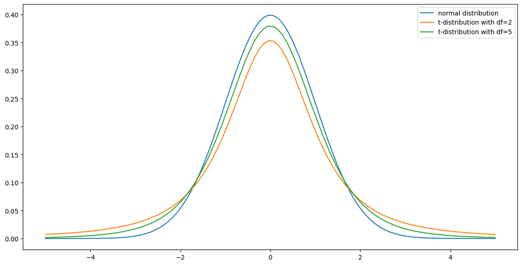

```python
import numpy as np
import matplotlib.pyplot as plt
from scipy.stats import t, norm

X = np.linspace(-5, 5, 100)
Y_norm = norm.pdf(X)
Y_t_2 = t.pdf(X, df=2)
Y_t_5 = t.pdf(X, df=5)

plt.figure(figsize=(14, 7))
plt.plot(X, Y_norm, label="normal distribution")
plt.plot(X, Y_t_2, label="t-distribution with df=2")
plt.plot(X, Y_t_5, label="t-distribution with df=5")
plt.legend()
plt.show()
```

**5. What are the preliminary conditions for using t-test on our data?**

1. **All samples must have the same distribution**: All samples should be independent of each other, implying they are drawn from the same underlying distribution.
2. **T-testing relies on normal behavior**: As previously explained, the t-distribution is an extension of the normal distribution. To appropriately employ t-testing, it's essential for the data under examination to exhibit normal behavior.
3. **The groups being compared must exhibit homogeneity of variances**: It's important that the variances of the compared groups are similar. This condition ensures the validity of certain types of t-tests, particularly the independent samples t-test.

**6. Read about some other types of tests that are used in scientific research. Write a line about each of them.**

1. **Chi-Square Test**: This test is used to determine whether there is a significant association between two categorical variables. It compares observed frequencies with expected frequencies under the null hypothesis of independence.
2. **ANOVA (Analysis of Variance)**: ANOVA is used to compare means across two or more groups. It assesses whether there are statistically significant differences between the means of the groups based on the variance within and between the groups.
3. **Regression Analysis**: Regression analysis is used to examine the relationship between one dependent variable and one or more independent variables. It helps to understand how the value of the dependent variable changes when one or more independent variables are varied.
4. **Correlation Analysis**: Correlation analysis measures the strength and direction of the linear relationship between two continuous variables. It provides insights into how changes in one variable are associated with changes in another variable.